# Tree-based methods, polynomial regression, k-means clustering

2023-12-09

## Q1 - Polynomial Regression

### a) Fit a cubic polynomial regression

We will use the `Boston` dataset from the library `Mass`. Also, we rely on the `caret` package to streamline our training, validating, and testing procedure.

```r
# Load libraries
library(MASS)
library(caret)
library(dplyr)
library(tidyverse)
library(ISLR)
library(tree)
library(randomForest)
library(gbm)
library(reshape2)
# Load dataset
data(Boston)
head(Boston)
```

```
##      crim zn indus chas   nox    rm  age    dis rad tax ptratio  black lstat
## 1 0.00632 18  2.31    0 0.538 6.575 65.2 4.0900   1 296    15.3 396.90  4.98
## 2 0.02731  0  7.07    0 0.469 6.421 78.9 4.9671   2 242    17.8 396.90  9.14
## 3 0.02729  0  7.07    0 0.469 7.185 61.1 4.9671   2 242    17.8 392.83  4.03
## 4 0.03237  0  2.18    0 0.458 6.998 45.8 6.0622   3 222    18.7 394.63  2.94
## 5 0.06905  0  2.18    0 0.458 7.147 54.2 6.0622   3 222    18.7 396.90  5.33
## 6 0.02985  0  2.18    0 0.458 6.430 58.7 6.0622   3 222    18.7 394.12  5.21
##   medv
## 1 24.0
## 2 21.6
## 3 34.7
## 4 33.4
## 5 36.2
## 6 28.7
```

Then, we fit the polynomial regression using the lm() function.

```r
# Fit lm()
fit_cubic <- lm(nox ~ poly(dis, 3), data = Boston)
summary(fit_cubic)
```

```
##
## Call:
## lm(formula = nox ~ poly(dis, 3), data = Boston)
##
## Residuals:
##       Min        1Q    Median        3Q       Max
## -0.121130 -0.040619 -0.009738  0.023385  0.194904
##
## Coefficients:
##                Estimate Std. Error t value Pr(>|t|)
## (Intercept)    0.554695   0.002759 201.021  < 2e-16 ***
## poly(dis, 3)1 -2.003096   0.062071 -32.271  < 2e-16 ***
## poly(dis, 3)2  0.856330   0.062071  13.796  < 2e-16 ***
## poly(dis, 3)3 -0.318049   0.062071  -5.124 4.27e-07 ***
## ---
## Signif. codes:  0 '***' 0.001 '**' 0.01 '*' 0.05 '.' 0.1 ' ' 1
##
## Residual standard error: 0.06207 on 502 degrees of freedom
## Multiple R-squared:  0.7148, Adjusted R-squared:  0.7131
## F-statistic: 419.3 on 3 and 502 DF,  p-value: < 2.2e-16
```

Next, we plot the results, including the 95% confidence interval, scatterplot, and predicted values

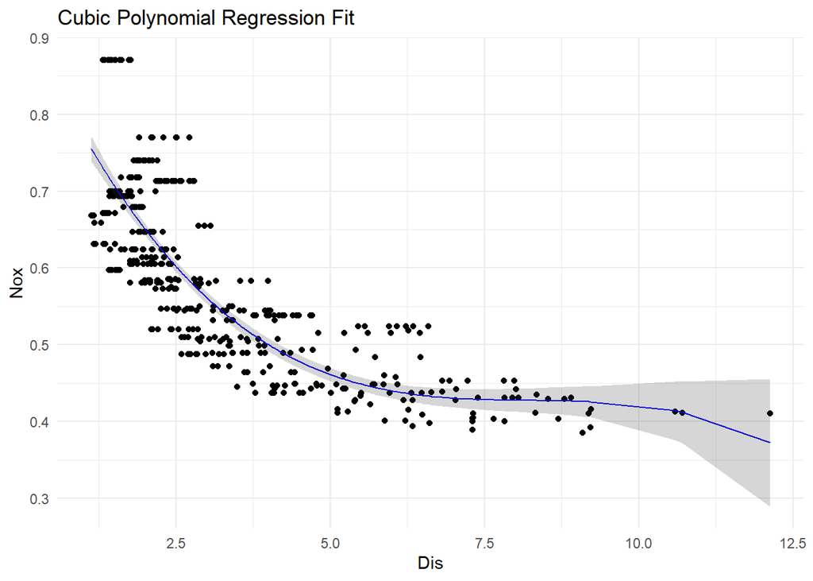

```r
# Create a dataframe for predictions and intervals
pred_data <- data.frame(dis = Boston$dis, nox = Boston$nox)
preds <- predict(fit_cubic, newdata = pred_data, interval = "confidence")

# Add predictions and intervals to the dataframe
pred_data$fit <- preds[, "fit"]
pred_data$lwr <- preds[, "lwr"]
pred_data$upr <- preds[, "upr"]

# Create the plot
ggplot(Boston, aes(x = dis, y = nox)) +
  # Scatterplot
  geom_point() +
  # Predicted vales
  geom_line(data = pred_data, aes(x = dis, y = fit), color = "blue") +
  # Confience Interval
  geom_ribbon(data = pred_data, aes(ymin = lwr, ymax = upr), alpha = 0.2) +
  labs(title = "Cubic Polynomial Regression Fit",
       x = "Dis",
       y = "Nox") +
  theme_minimal()
```

### b) Finding Optimal degree using Cross Validation

Here, we use the `caret` package to train a polynomial model based on *repeated* k-fold cross validation. We use **k = 10** and repeat the run 10 times.

```r
# Setting up 10-fold cross-validation
set.seed(1998)

# Define the control for cross-validation
control <- trainControl(method = "repeatedcv", repeats = 10, number = 10)

# Train polynomial models with cross-validation using for loop
degrees <- 1:3

# Initialize for loop
for (d in degrees) {
name <- paste0("fit_cv_", d)
fit_cv_formula <- as.formula(paste0("nox ~ poly(dis, ", d, ")"))
fit_cv <- train(fit_cv_formula, data = Boston, method = "lm",
                trControl = control)
assign(name, fit_cv)
}

# Review the results
resamps <- resamples(list(deg1 = fit_cv_1,
                          deg2 = fit_cv_2,
                          deg3 = fit_cv_3))

summary(resamps)
```

```
##
## Call:
## summary.resamples(object = resamps)
##
## Models: deg1, deg2, deg3
## Number of resamples: 100
##
## MAE
##            Min.    1st Qu.     Median       Mean    3rd Qu.       Max. NA's
## deg1 0.04144488 0.05286378 0.05656953 0.05720893 0.06175498 0.07157905    0
## deg2 0.03837509 0.04526285 0.04829515 0.04841863 0.05181227 0.06222134    0
## deg3 0.03451152 0.04359737 0.04682794 0.04657615 0.04957046 0.05751765    0
##
## RMSE
##            Min.    1st Qu.     Median       Mean    3rd Qu.       Max. NA's
## deg1 0.05200339 0.06782988 0.07414459 0.07380501 0.08001407 0.08984977    0
## deg2 0.05048784 0.05905250 0.06275102 0.06345451 0.06820946 0.07828474    0
## deg3 0.04855722 0.05798053 0.06167577 0.06187108 0.06572707 0.07312150    0
##
## Rsquared
##           Min.   1st Qu.    Median      Mean   3rd Qu.      Max. NA's
## deg1 0.4843587 0.5692394 0.6061293 0.6052117 0.6372133 0.7464681    0
## deg2 0.6070539 0.6792941 0.7096660 0.7059535 0.7358632 0.8005906    0
## deg3 0.6196609 0.6952454 0.7203964 0.7208450 0.7518217 0.8176413    0
```

We can see that *RMSE, MAE* and *R-squared* all indicate that **degree 3** model best describes the given data.

## Q2 - Regression Trees and related approaches

In this question, we seek to predict “sales” using regression trees and related approaches.

Note that `Carseats` dataset is stored in the library `ISLR`.

### a) Split data set such that half is training and other half is test set

```r
# Load Carseats dataset
data("Carseats")
head(Carseats)
```

```
##   Sales CompPrice Income Advertising Population Price ShelveLoc Age Education
## 1  9.50       138     73          11        276   120       Bad  42        17
## 2 11.22       111     48          16        260    83      Good  65        10
## 3 10.06       113     35          10        269    80    Medium  59        12
## 4  7.40       117    100           4        466    97    Medium  55        14
## 5  4.15       141     64           3        340   128       Bad  38        13
## 6 10.81       124    113          13        501    72       Bad  78        16
##   Urban  US
## 1   Yes Yes
## 2   Yes Yes
## 3   Yes Yes
## 4   Yes Yes
## 5   Yes  No
## 6    No Yes
```

```r
Carseats %>% str()
```

```
## 'data.frame':    400 obs. of  11 variables:
##  $ Sales      : num  9.5 11.22 10.06 7.4 4.15 ...
##  $ CompPrice  : num  138 111 113 117 141 124 115 136 132 132 ...
##  $ Income     : num  73 48 35 100 64 113 105 81 110 113 ...
##  $ Advertising: num  11 16 10 4 3 13 0 15 0 0 ...
##  $ Population : num  276 260 269 466 340 501 45 425 108 131 ...
##  $ Price      : num  120 83 80 97 128 72 108 120 124 124 ...
##  $ ShelveLoc  : Factor w/ 3 levels "Bad","Good","Medium": 1 2 3 3 1 1 3 2 3 3 ...
##  $ Age        : num  42 65 59 55 38 78 71 67 76 76 ...
##  $ Education  : num  17 10 12 14 13 16 15 10 10 17 ...
##  $ Urban      : Factor w/ 2 levels "No","Yes": 2 2 2 2 2 1 2 2 1 1 ...
##  $ US         : Factor w/ 2 levels "No","Yes": 2 2 2 2 1 2 1 2 1 2 ...
```

```r
# Split dataset into half using sampling method
set.seed(1998)
idx <- sample(1:nrow(Carseats))
train_idx <- idx[1:(length(idx)/2)]
test_idx <- idx[(length(idx)/2+1):length(idx)]

# Check that there is no duplicate
sum(test_idx == train_idx)
```

```
## [1] 0
```

```r
train <- Carseats[train_idx,]
test <- Carseats[test_idx,]
Sales.test <- Carseats[test_idx, 'Sales']

head(train)
```

```
##     Sales CompPrice Income Advertising Population Price ShelveLoc Age Education
## 338  8.61       130     38           0        283   102    Medium  80        15
## 137  5.17       131     75           0         10   120       Bad  31        18
## 213 12.04       145     69          19        501   105    Medium  45        11
## 207  4.97       162     67           0         27   160    Medium  77        17
## 39   6.59       109     73           0        454   102    Medium  65        15
## 286  7.60       146     26          11        261   131    Medium  39        10
##     Urban  US
## 338   Yes  No
## 137    No  No
## 213   Yes Yes
## 207   Yes Yes
## 39    Yes  No
## 286   Yes Yes
```

```r
head(test)
```

```
##     Sales CompPrice Income Advertising Population Price ShelveLoc Age Education
## 15  11.17       107    117          11        148   118      Good  52        18
## 231  5.16       115     60           0        119   114       Bad  38        14
## 84   4.42       109     36           7        468    94       Bad  56        11
## 148 10.51       140     54           9        402   119      Good  41        16
## 384  9.35        98    117           0         76    68    Medium  63        10
## 267  9.10       128     93          12        343   112      Good  73        17
##     Urban  US
## 15    Yes Yes
## 231    No  No
## 84    Yes Yes
## 148    No Yes
## 384   Yes  No
## 267    No Yes
```

### b) Fit a regression Tree to the training set

Also, plot the tree and report the MSE value

```r
# Fit regression tree
tree.Carseats <- tree(Sales ~ ., data = Carseats, subset = train_idx)
summary(tree.Carseats)
```

```
##
## Regression tree:
## tree(formula = Sales ~ ., data = Carseats, subset = train_idx)
## Variables actually used in tree construction:
## [1] "ShelveLoc"   "Price"       "CompPrice"   "Age"         "Income"
## [6] "Advertising" "Education"   "Population"
## Number of terminal nodes:  18
## Residual mean deviance:  2.169 = 394.7 / 182
## Distribution of residuals:
##     Min.  1st Qu.   Median     Mean  3rd Qu.     Max.
## -3.27900 -1.08100 -0.01183  0.00000  0.83700  3.31500
```

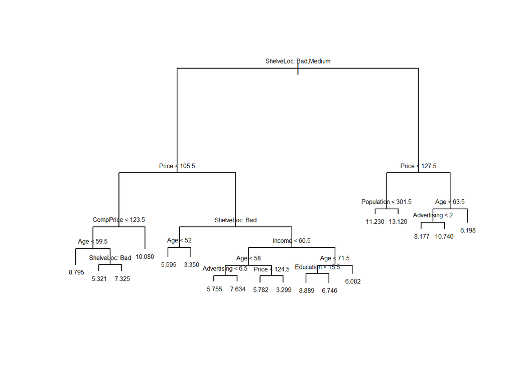

```r
# Plot tree
plot(tree.Carseats)
text(tree.Carseats, pretty = 0, cex = 0.5)
```

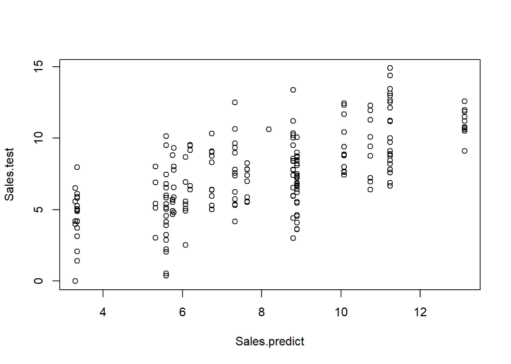

```r
## Find test MSE

# Predicted val
Sales.predict <- predict(tree.Carseats, newdata = test)
plot(Sales.predict, Sales.test)
```

```r
# test MSE
MSE.tree <- mean((Sales.predict - Sales.test)^2)
print(MSE.tree)
```

```
## [1] 5.291413
```

### c) Random Forest approach.

Report numerical value of test error and use `importance()` function to determine which variables are most important.

```r
# Fit random forest; setseed since random forest method uses resampling
set.seed(1998)
rf.Carseats <- randomForest(Sales ~ ., data = Carseats, subset = train_idx, importance = TRUE)
rf.Carseats
```

```
##
## Call:
##  randomForest(formula = Sales ~ ., data = Carseats, importance = TRUE,      subset = train_idx)
##                Type of random forest: regression
##                      Number of trees: 500
## No. of variables tried at each split: 3
##
##           Mean of squared residuals: 3.257222
##                     % Var explained: 59.34
```

Next, we plot the test Sales values against the predicted values generated by the random forest

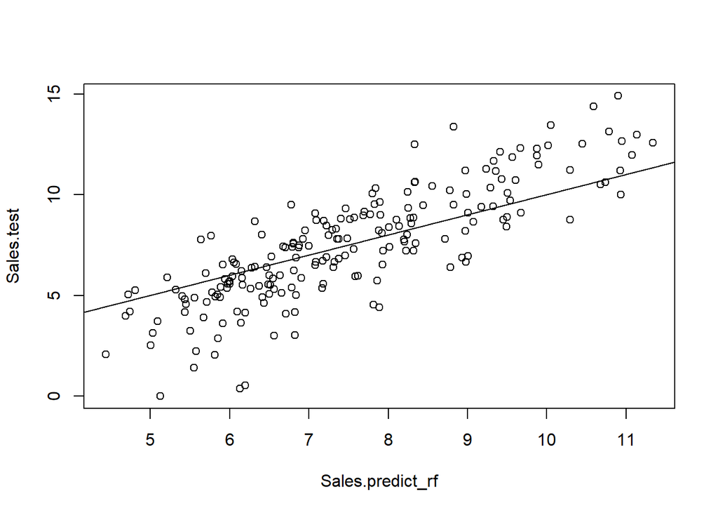

```r
# predicted val
Sales.predict_rf <- predict(rf.Carseats, newdata = test)
plot(Sales.predict_rf, Sales.test)
abline(0,1)
```

Now, we use the `importance()` function to deter which variables are important

```r
importance(rf.Carseats)
```

```
##                 %IncMSE IncNodePurity
## CompPrice   11.31699635     135.49263
## Income       4.72982344     117.71616
## Advertising 11.35483826     149.13449
## Population  -0.65470982     102.48269
## Price       34.13986272     341.05589
## ShelveLoc   37.93697749     320.52814
## Age         18.93206265     216.48726
## Education    2.06200802      88.04451
## Urban        0.07840286      13.77550
## US           4.18690116      21.98332
```

### d) Try different sizes of subset of predictors when fitting RF

The default *m* for `mtry` value is set to *p*/3. Try smaller and larger *m* values and see how this affects the test error. Also, report the numerical MSE values used in building the different rf models.

We can compare different rf models using a for loop.

```r
# Initialize predictor
mtry_seq <- 1:10
rf.models <- list()

# Construct For loop
for (mtry in mtry_seq) {
  set.seed(1998)
  model <- randomForest(Sales ~ ., data = train, mtry = mtry)
  rf.models[[mtry]] <- model
}

# Calculate MSE values

mse_values <- numeric(length(mtry_seq))
names(mse_values) <- mtry_seq

for (mtry in mtry_seq) {
  pred_rf <- predict(rf.models[[mtry]], newdata = test)
  mse_values[mtry] <- mean((pred_rf - Sales.test)^2)
}

# Viewing the MSE for each mtry value
mse_values
```

```
##        1        2        3        4        5        6        7        8
## 4.651880 3.490477 3.018581 2.817624 2.678825 2.655097 2.591382 2.561628
##        9       10
## 2.572568 2.515455
```

We see that when we use all 10 predictors, the test *MSE* is the lowest at 2.51455.

#### Digression - Using train() function from caret package to find optimal mtry value

```r
# Use train() function from `caret` package

# Set control for 10-fold cross validation
control <- trainControl(method = "cv", number = 10)

# Define Tune Grid for `mtry` values
mtry_grid <- expand.grid(.mtry = 1:10)

# Train model
set.seed(1998)
rf_models <- train(Sales ~ ., data = train, method = 'rf', trControl = control, tuneGrid = mtry_grid)

rf_models$results
```

```
##    mtry     RMSE  Rsquared      MAE    RMSESD RsquaredSD     MAESD
## 1     1 2.234221 0.5951010 1.810884 0.1541731  0.1044822 0.1208482
## 2     2 1.977348 0.6461691 1.610099 0.1420499  0.1071533 0.1168833
## 3     3 1.849206 0.6774697 1.510135 0.1672068  0.1040274 0.1277317
## 4     4 1.813596 0.6705734 1.485122 0.2026144  0.1061766 0.1599819
## 5     5 1.777627 0.6725194 1.453309 0.2077935  0.1127080 0.1727974
## 6     6 1.768708 0.6702612 1.450950 0.2080085  0.1039551 0.1650333
## 7     7 1.756305 0.6638435 1.446225 0.2243636  0.1031891 0.1832279
## 8     8 1.756661 0.6614542 1.443899 0.2363550  0.1049592 0.1965833
## 9     9 1.749963 0.6613476 1.443302 0.2345548  0.1057605 0.2000621
## 10   10 1.747551 0.6583093 1.437828 0.2485964  0.1103075 0.2084611
```

Note that using RMSE as the standard for selecting best model, `mtry = 10` produces the best model based on 10-fold cross validation.

Now, I compute test MSE values for the random forest using `mtry = 10`.

```r
# Predidcted values
predicted_caret <- predict(rf_models, newdata = test)

# Test MSE
MSE_caret <- mean((predicted_caret - Sales.test)^2)
print(MSE_caret)
```

```
## [1] 2.606798
```

We see that the test MSE value is similar to that of `mse_values`.

## Q3 - Boosting and Random Forest

We use boosting to predict “Salary” in the `Hitters` data set. the data set is stored in the library `ISLR`.

### a) Remove the observations for whom the salary information is unknown, and then log-transform the salaries.

```r
# Load data
Hitters <- ISLR::Hitters
head(Hitters)
```

```
##                   AtBat Hits HmRun Runs RBI Walks Years CAtBat CHits CHmRun
## -Andy Allanson      293   66     1   30  29    14     1    293    66      1
## -Alan Ashby         315   81     7   24  38    39    14   3449   835     69
## -Alvin Davis        479  130    18   66  72    76     3   1624   457     63
## -Andre Dawson       496  141    20   65  78    37    11   5628  1575    225
## -Andres Galarraga   321   87    10   39  42    30     2    396   101     12
## -Alfredo Griffin    594  169     4   74  51    35    11   4408  1133     19
##                   CRuns CRBI CWalks League Division PutOuts Assists Errors
## -Andy Allanson       30   29     14      A        E     446      33     20
## -Alan Ashby         321  414    375      N        W     632      43     10
## -Alvin Davis        224  266    263      A        W     880      82     14
## -Andre Dawson       828  838    354      N        E     200      11      3
## -Andres Galarraga    48   46     33      N        E     805      40      4
## -Alfredo Griffin    501  336    194      A        W     282     421     25
##                   Salary NewLeague
## -Andy Allanson        NA         A
## -Alan Ashby        475.0         N
## -Alvin Davis       480.0         A
## -Andre Dawson      500.0         N
## -Andres Galarraga   91.5         N
## -Alfredo Griffin   750.0         A
```

We first drop NA values for `Salary`.

```r
NA_idx <- which(is.na(Hitters$Salary))
Hitters_v1 <- Hitters[-NA_idx,]
sum(is.na(Hitters_v1))
```

```
## [1] 0
```

We deleted 59 observations that returned NA Salary values.

Next, we log transform the salaries and append it to original dataset.

```r
Hitters_v2 <- Hitters_v1
Hitters_v2$logSalary <- log(Hitters_v1$Salary)
head(Hitters_v2)
```

```
##                   AtBat Hits HmRun Runs RBI Walks Years CAtBat CHits CHmRun
## -Alan Ashby         315   81     7   24  38    39    14   3449   835     69
## -Alvin Davis        479  130    18   66  72    76     3   1624   457     63
## -Andre Dawson       496  141    20   65  78    37    11   5628  1575    225
## -Andres Galarraga   321   87    10   39  42    30     2    396   101     12
## -Alfredo Griffin    594  169     4   74  51    35    11   4408  1133     19
## -Al Newman          185   37     1   23   8    21     2    214    42      1
##                   CRuns CRBI CWalks League Division PutOuts Assists Errors
## -Alan Ashby         321  414    375      N        W     632      43     10
## -Alvin Davis        224  266    263      A        W     880      82     14
## -Andre Dawson       828  838    354      N        E     200      11      3
## -Andres Galarraga    48   46     33      N        E     805      40      4
## -Alfredo Griffin    501  336    194      A        W     282     421     25
## -Al Newman           30    9     24      N        E      76     127      7
##                   Salary NewLeague logSalary
## -Alan Ashby        475.0         N  6.163315
## -Alvin Davis       480.0         A  6.173786
## -Andre Dawson      500.0         N  6.214608
## -Andres Galarraga   91.5         N  4.516339
## -Alfredo Griffin   750.0         A  6.620073
## -Al Newman          70.0         A  4.248495
```

### b) Create training set of first 200 observations and test set of remaining observations

Notice that we have in total 263 observations, so the test set will contain 63 observations.

```r
# Split dataset into train/test set
train <- Hitters_v2[1:200,]
test <- Hitters_v2[201:nrow(Hitters_v2),]
```

### c) Boosting

Perform boosting on the training set with 1,000 trees for the range of values of the shrinkage parameter λ below. Produce a plot with different shrinkage values on the x-axis and the corresponding training set MSE on the y-axis.

(Use λ = (0.0001, 0.0002, 0.0005, 0.001, 0.002, 0.005, 0.01, 0.02, 0.05, 0.1, 0.2), with “interaction.depth=4” for (c) and (d).)

```r
# Set up grid for shrinkage parameter and initialize mse
lambda_values <- c(0.0001, 0.0002, 0.0005, 0.001, 0.002, 0.005, 0.01, 0.02, 0.05, 0.1, 0.2)
mse_train <- numeric(length(lambda_values))
names(mse_train) <- lambda_values

# Perform boosting using gbm() function. Set seed for reproducibility
for (i in seq_along(lambda_values)) {
  set.seed(1998)
  model_boosting <- gbm(Salary ~ ., data = train, distribution = "gaussian",
               n.trees = 1000, interaction.depth = 4,
               shrinkage = lambda_values[i])
  Salary_preds <- predict(model_boosting, train, n.trees = 1000)
  mse_train[i] <- mean((Salary_preds - train$Salary)^2)
}

mse_train
```

```
##        1e-04        2e-04        5e-04        0.001        0.002        0.005
## 1.882170e+05 1.585060e+05 9.618853e+04 4.545062e+04 1.733735e+04 7.764863e+03
##         0.01         0.02         0.05          0.1          0.2
## 4.571851e+03 2.228893e+03 3.840433e+02 2.285804e+01 6.352354e-01
```

Notice we use `distribution = "gaussian"` because we are dealing with regression. We would use `distribution = "binomial"` if we were to solve a classification problem.

Now we produce a plot with different shrinkage values and training set MSE on the y-axis

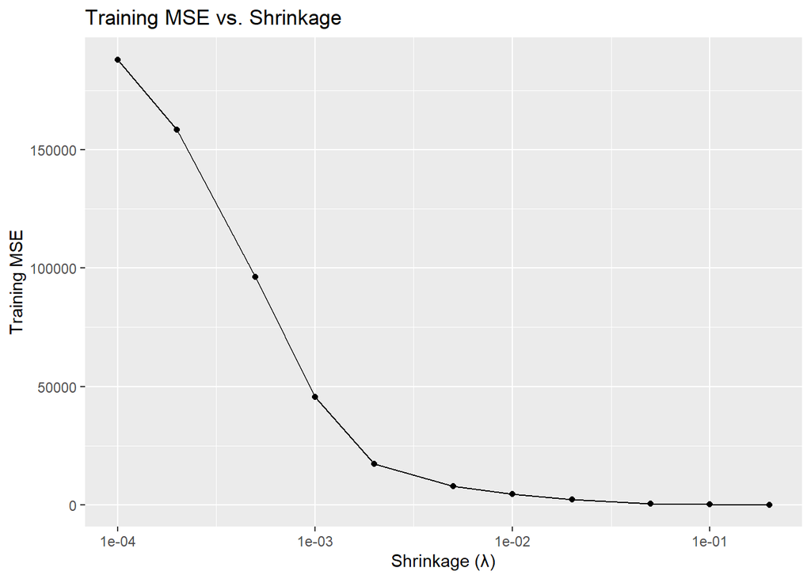

```r
# Data frame for plotting
plot_data <- data.frame(lambda = lambda_values, MSE = mse_train)

# Construct plot using ggplot2
ggplot(plot_data, aes(x = lambda, y = MSE)) +
  geom_line() +
  geom_point() +
  scale_x_log10() +
  labs(title = "Training MSE vs. Shrinkage", x = "Shrinkage (λ)", y = "Training MSE")
```

We see a monotonic decreasing curve of MSE as shrinkage increases.

### d) Generate plot using Test MSE

```r
# Set up grid for shrinkage parameter and initialize mse
lambda_values <- c(0.0001, 0.0002, 0.0005, 0.001, 0.002, 0.005, 0.01, 0.02, 0.05, 0.1, 0.2)
mse_test <- numeric(length(lambda_values))
names(mse_test) <- lambda_values

# Perform boosting using gbm() function. Set seed for reproducibility
for (i in seq_along(lambda_values)) {
  set.seed(1998)
  model_boosting <- gbm(Salary ~ ., data = train, distribution = "gaussian",
               n.trees = 1000, interaction.depth = 4,
               shrinkage = lambda_values[i])
  Salary_preds <- predict(model_boosting, test, n.trees = 1000)
  mse_test[i] <- mean((Salary_preds - test$Salary)^2)
}

mse_test
```

```
##      1e-04      2e-04      5e-04      0.001      0.002      0.005       0.01
## 110076.839  88923.962  46488.306  15594.843   2839.056   4553.903   6992.674
##       0.02       0.05        0.1        0.2
##   9463.694  11432.819  12466.775  13554.312
```

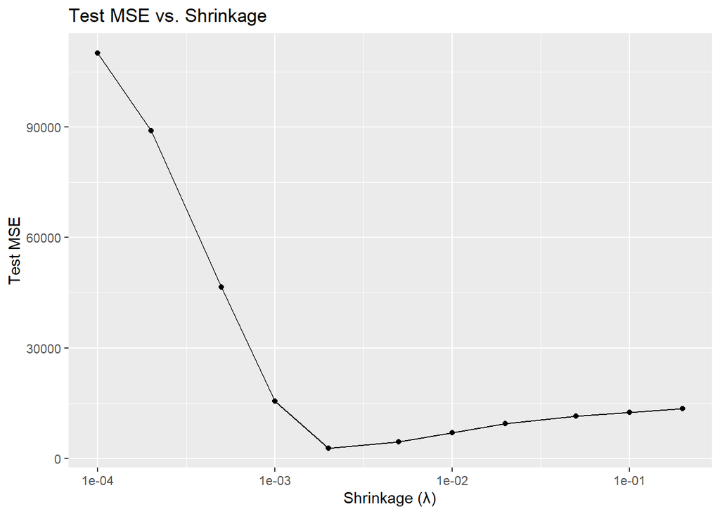

```r
# Data frame for plotting
plot_data$MSE2 <- mse_test

# Construct plot using ggplot2
ggplot(plot_data, aes(x = lambda, y = MSE2)) +
  geom_line() +
  geom_point() +
  scale_x_log10() +
  labs(title = "Test MSE vs. Shrinkage", x = "Shrinkage (λ)", y = "Test MSE")
```

As expected, we observe that the curve is not monotonic; the Test MSE decreases up to a certain shrinkage value and then starts to increase.

We can also visualize by plotting two curves in a single plot. To do so, we first convert wide format to long format, which is more consistent with ggplot2’s philosophy of **mapping various aesthetics to a single variable**.

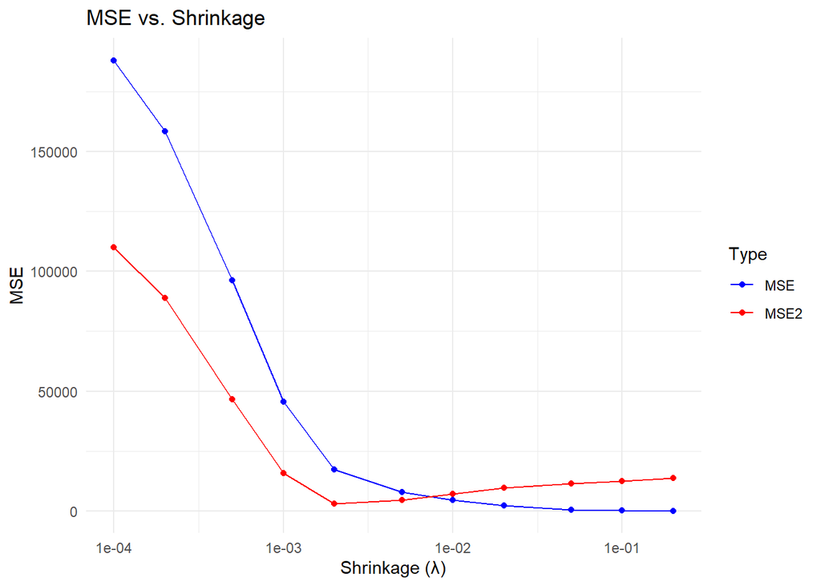

```r
# Reshaping the dataframe from wide to long format
long_data <- melt(plot_data, id.vars = 'lambda', variable.name = 'Type', value.name = 'MSE')

# Construct plot
ggplot(long_data, aes(x = lambda, y = MSE, color = Type)) +
  geom_line() +
  geom_point() +
  scale_x_log10() +
  labs(title = "MSE vs. Shrinkage", x = "Shrinkage (λ)", y = "MSE") +
  theme_minimal() +
  scale_color_manual(values = c("MSE" = "blue", "MSE2" = "red"))
```

### e) Compare random forest with boosting

We compare test MSE from **d)** with test MSE from fitting a random forest using default options.

```r
# Fit default random forest

fit_rf <- randomForest(Salary ~ ., data = train)

preds_rf <- predict(fit_rf, newdata = test)

MSE_test_rf <- mean((preds_rf - test$Salary)^2)

MSE_test_rf
```

```
## [1] 8760.002
```

The value of test MSE using the default options of the randomForest() function is 8760.0015444, which is larger than the minimum test MSE value derived from the boosting method, which is 2839.0564341

## Q4) K-Means Algorithm from scratch

We build four functions in order to build the K-Means Algorithm

1. initialize_centroids(): Randomly sample *k* data points and set them as initial centroids.
2. cluster_assignment(): Assign clusters for all data points based on Euclidean distance.
3. update_centroids(): Update new centroids by taking mean of all points within each cluster.
4. K_means(): algorithm that takes parameters *data*, *k*, *max_iter = 100* and incorporate aforementioned custom functions.

```r
# Initialize centroids

initialize_centroids <- function(data, k) {
  sample(nrow(data), k)
}

# Construct cluster_assignment function
cluster_assignment <- function(data, centroids) {
  apply(data, 1, function(point) {
    distances <- apply(centroids, 1, function(centroid) {
      sqrt(sum((point - centroid)^2))
    })
    which.min(distances)
  })
}
```

Some points to notice.

- cluster_assignment() function returns a vector of integers that correspond to the cluster assignments of each data point.
- `initialize_centroids()` returns a vector of centroid *indices*. Thus, we use the below code to find the actual centroids.

```r
centroids_idx <- initialize_centroids(data, k)
centroids <- data[centroids_idx, , drop = FALSE]
```

We add the `drop = FALSE` argument so we can maintain the structure (i.e., data frame) even if the subsetting results in a single row/column object.

Now we move on to the next custom function.

```r
# Construct update_centroids() function
update_centroids <- function(data, clusters, k) {
  new_centroids <- matrix(nrow = k, ncol = ncol(data))
  for (i in 1:k) {
    new_centroids[i, ] <- colMeans(data[clusters == i, , drop = FALSE])
  }
  new_centroids
}
```

Since each row is an observation, we use colMeans() function to take the mean of all data points (calculate mean *across* columns).

Finally, taking all the above functions, together, we build the K-means algorithm.

```r
# Construct k-means algorithm
K_means <- function(data, k, max_iter = 100) {
  centroids_idx <- initialize_centroids(data, k)
  centroids <- data[centroids_idx, , drop = FALSE]

  for (i in 1:max_iter) {
    clusters <- assign_clusters(data, centroids)
    new_centroids <- update_centroids(data, clusters, k)

    if (all(centroids == new_centroids)) break
    centroids <- new_centroids
  }

  list(centroids = centroids, clusters = clusters)
}
```

### Test K-means aglo

before we can test our custom defined k-means function, we first build a random data matrix.

```r
# library(MASS)

# generate random data matrix d1 and d2
Sigma <- matrix(c(1.5, 0.4, 0.4, 1.5), nrow = 2)
mu1 <- c(0, -2)
mu2 <- c(6, 2)
n <- 200
d1 <- mvrnorm(n = n/2, mu = mu1, Sigma = Sigma)
d2 <- mvrnorm(n = n/2, mu = mu2, Sigma = Sigma)
x <- rbind(d1, d2)
```

data matrices *d1* and *d2* are 2D and each has 100 observations. Next, we plot this data to visually confirm that there exists some clusters.

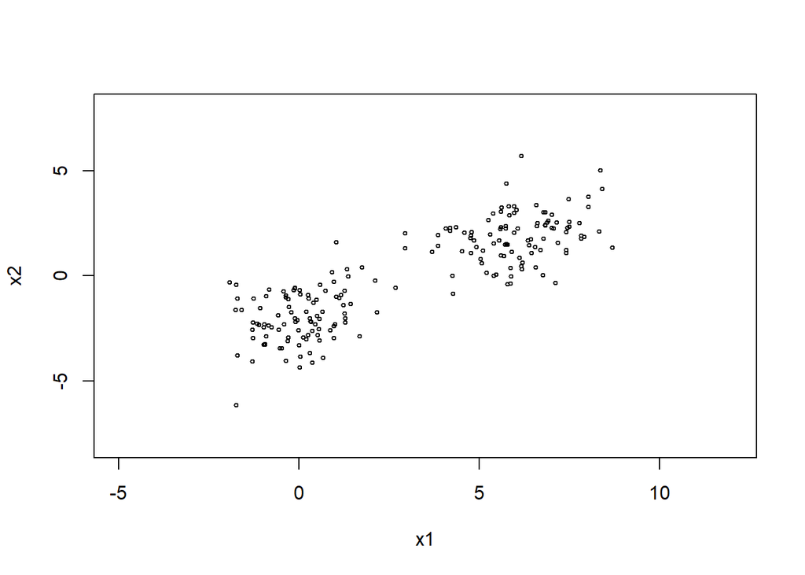

```r
# Plot data

plot(x,
pch = 1, cex = 0.5, col = 1,
xlab = "x1", ylab = "x2",
xlim = c(-5, 12), ylim = c(-8, 8))
```

### a) Initialize centroids

```r
# Initialize centroids m1 and m2
m1 <- c(-5, -5)
m2 <- c(5, -5)
```

`points(x = m1[1], y = m1[2], pch = 3, cex = 1, col = 1)` and `points(x = m2[1], y = m2[2], pch = 3, cex = 1, col = 2)`

are commands to add m1 and m2 in the plot.

### b) Assign cluster

To use our custom-built function cluster_assignment(), we must first take the individuals centroids *m1 & m2* and integrate them into a single matrix.

```r
# Construct matrix of centroids
initial_centroids <- matrix(c(m1,m2), ncol = 2, byrow = TRUE)

rownames(initial_centroids) <- c('m1', 'm2')

initial_centroids
```

```
##    [,1] [,2]
## m1   -5   -5
## m2    5   -5
```

Next we assign each observation in x a cluster.

```r
# Assign clusters
initial_clusters <- cluster_assignment(x, initial_centroids)
initial_clusters
```

```
##   [1] 1 2 2 2 1 2 1 1 2 2 1 1 1 1 1 1 1 2 1 2 2 1 2 2 2 1 2 2 2 2 1 2 1 1 1 1 2
##  [38] 2 2 1 2 1 1 1 1 2 1 2 1 2 1 2 1 2 2 1 1 1 2 1 2 2 1 2 2 1 2 1 2 2 1 2 2 1
##  [75] 2 1 1 2 1 2 2 2 1 1 2 2 2 2 2 2 2 2 1 1 1 1 2 1 1 2 2 2 2 2 2 2 2 2 2 2 2
## [112] 2 2 2 2 2 2 2 2 2 2 2 2 2 2 2 2 2 2 2 2 2 2 2 2 2 2 2 2 2 2 2 2 2 2 2 2 2
## [149] 2 2 2 2 2 2 2 2 2 2 2 2 2 2 2 2 2 2 2 2 2 2 2 2 2 2 2 2 2 2 2 2 2 2 2 2 2
## [186] 2 2 2 2 2 2 2 2 2 2 2 2 2 2 2
```

We go on to plot the points, this time using color to distinguish points from different clusters.

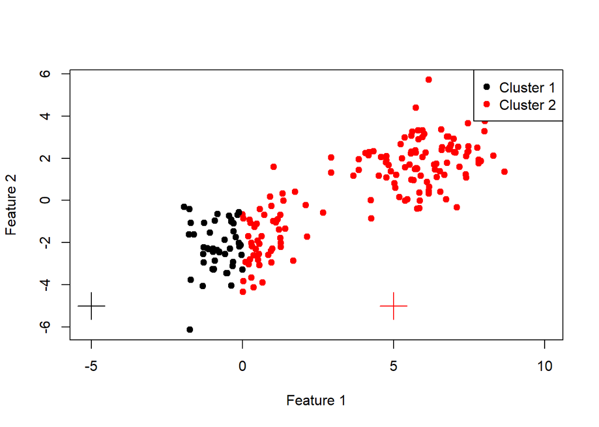

```r
# Plotting the data
plot(x, xlim = c(-5.1, 10), col = ifelse(initial_clusters == 1, "black", "red"), pch = 19, xlab = "Feature 1", ylab = "Feature 2")
legend("topright", legend = c("Cluster 1", "Cluster 2"), col = c("black", "red"), pch = 19)
points(x = m1[1], y = m1[2], pch = 3, cex = 3, col = "black")
points(x = m2[1], y = m2[2], pch = 3, cex = 3, col = "red")
```

We also try plotting use ggplot2.

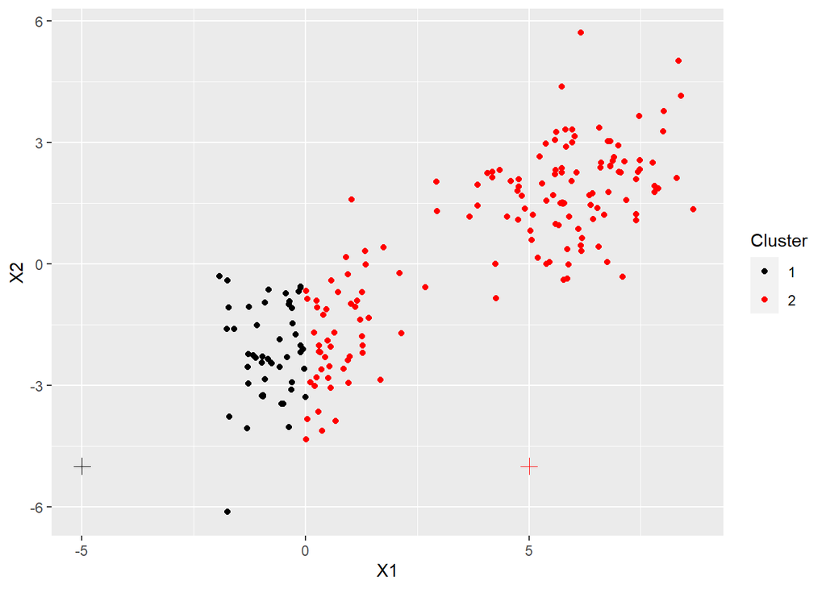

```r
# Combine data with cluster assignments
plot_data <- data.frame(x, Cluster = factor(initial_clusters))

# Plot
ggplot_obj <- ggplot(plot_data, aes(x = X1, y = X2, color = Cluster)) +
  geom_point() +
  scale_color_manual(values = c("black", "red")) +
  labs(color = "Cluster", x = "X1", y = "X2") +
  geom_point(aes(x = m1[1], y = m1[2]), color = "black", size = 3, shape = 3) +
  geom_point(aes(x = m2[1], y = m2[2]), color = "red", size = 3, shape = 3)


# Print the plot
print(ggplot_obj)
```

Next, we compute the objective value, which is the sum of the squared distances between each point and the centroid of its assigned cluster.

We do this in a two step process. First, we construct a custom defined function to compute the distances. Then, we apply the function to our data.

```r
# Build function to calculate distances
compute_distance <- function(data, clusters, centroids) {
  total_distance <- 0
  for (i in 1:nrow(data)) {
    cluster <- clusters[i]
    point <- data[i, ]
    centroid <- centroids[cluster, ]
    total_distance <- total_distance + sum((point - centroid)^2)
  }
  return(total_distance)
}

compute_distance(x, initial_clusters, initial_centroids)
```

```
## [1] 8010.504
```

The objective value is **8010.5040875**.

### c) Update Centroids

```r
centroids_v2 <- update_centroids(x, initial_clusters, 2)
centroids_v2
```

```
##            [,1]       [,2]
## [1,] -0.7919093 -2.1829373
## [2,]  4.2765375  0.6601992
```

Now we plot the new cluster centers and also compute the obj value again.

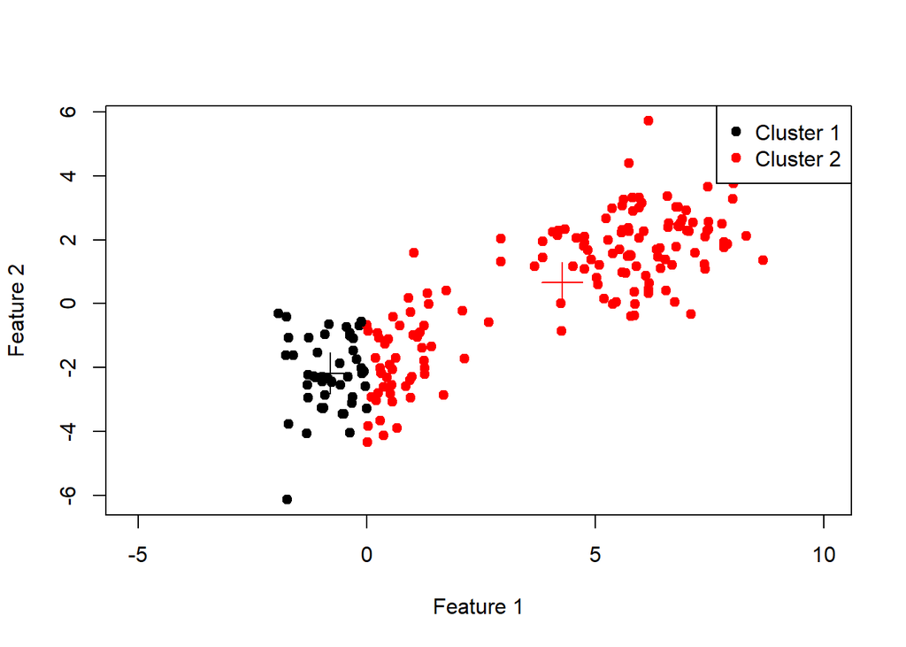

```r
plot(x, xlim = c(-5.1, 10), col = ifelse(initial_clusters == 1, "black", "red"), pch = 19, xlab = "Feature 1", ylab = "Feature 2")
legend("topright", legend = c("Cluster 1", "Cluster 2"), col = c("black", "red"), pch = 19)
points(x = centroids_v2[1,1], y = centroids_v2[1,2], pch = 3, cex = 3, col = "black")
points(x = centroids_v2[2,1], y = centroids_v2[2,2], pch = 3, cex = 3, col = "red")
```

We can see that the updated centroids represent a much better cluster center than the initial centroids. We confirm this fact via the new objective value.

```r
compute_distance(x, initial_clusters, centroids_v2)
```

```
## [1] 1830.288
```

The new objective value is 1830.2879822, which is a decrease of 6180.2161053 compared to the objective value calculated using initial centroids.

### d) Iterate a few times until convergence

#### Iteration 2

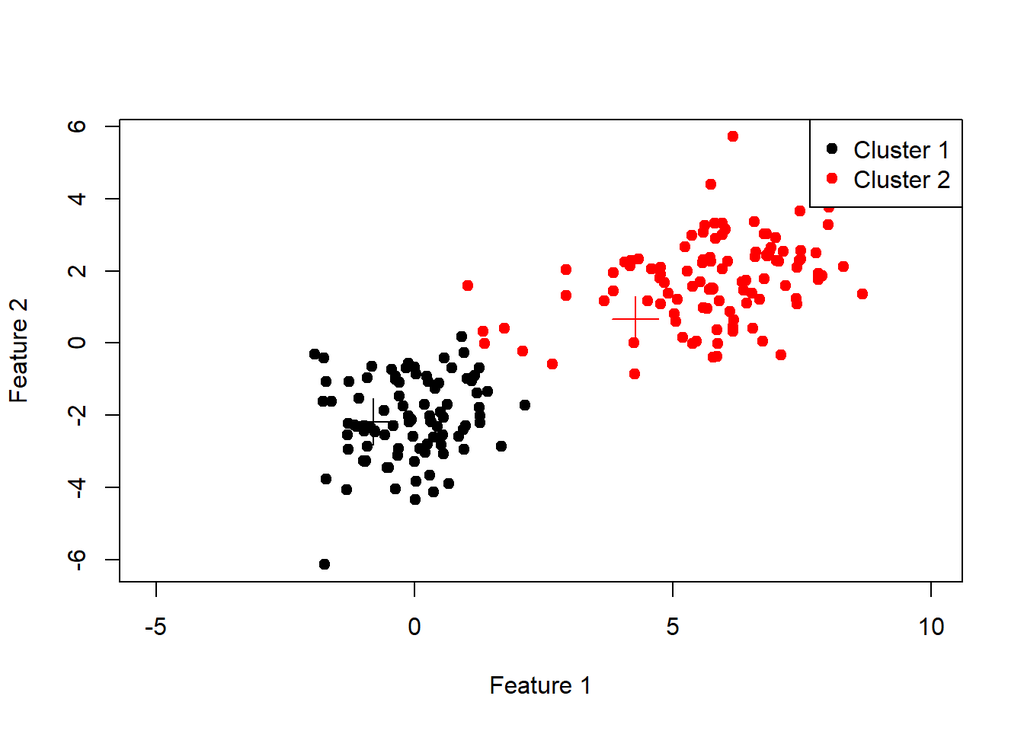

```r
# Update clusters
clusters_v2 <- cluster_assignment(x, centroids_v2)

plot(x, xlim = c(-5.1, 10), col = ifelse(clusters_v2 == 1, "black", "red"), pch = 19, xlab = "Feature 1", ylab = "Feature 2")
legend("topright", legend = c("Cluster 1", "Cluster 2"), col = c("black", "red"), pch = 19)
points(x = centroids_v2[1,1], y = centroids_v2[1,2], pch = 3, cex = 3, col = "black")
points(x = centroids_v2[2,1], y = centroids_v2[2,2], pch = 3, cex = 3, col = "red")
```

We see that many of the points belonging to cluster two are now classifed as cluster 1.

```r
# Update centroids
centroids_v3 <- update_centroids(x, clusters_v2, 2)
centroids_v3
```

```
##             [,1]      [,2]
## [1,] -0.08152951 -2.093603
## [2,]  5.79069433  1.778265
```

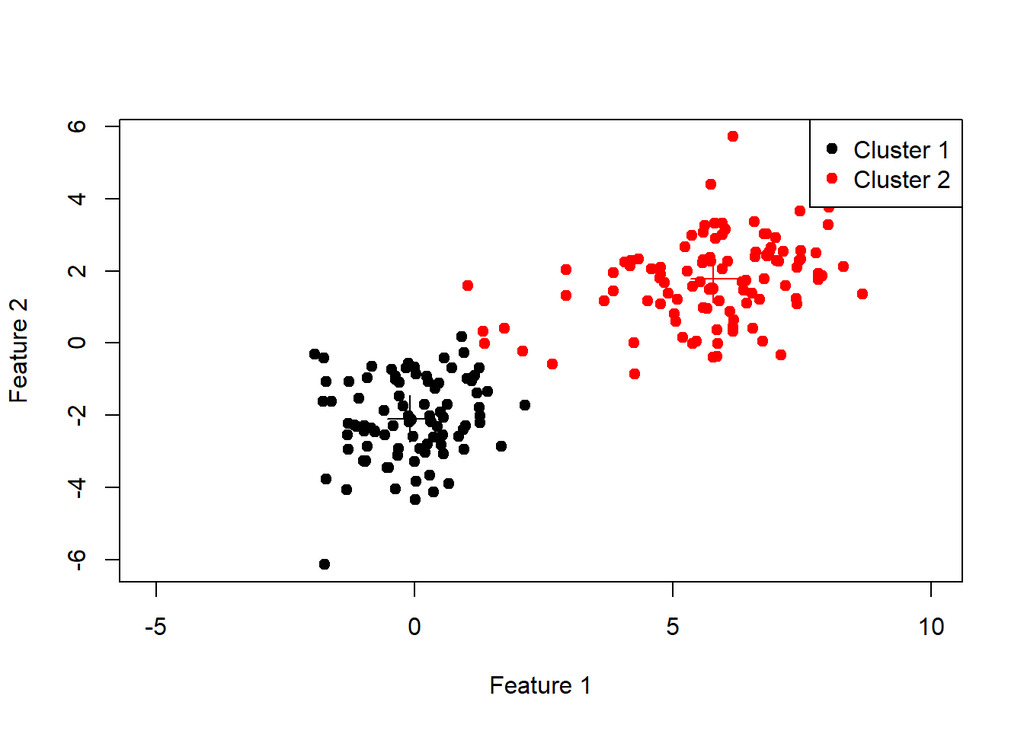

```r
# Plot with updated centroids
plot(x, xlim = c(-5.1, 10), col = ifelse(clusters_v2 == 1, "black", "red"), pch = 19, xlab = "Feature 1", ylab = "Feature 2")
legend("topright", legend = c("Cluster 1", "Cluster 2"), col = c("black", "red"), pch = 19)
points(x = centroids_v3[1,1], y = centroids_v3[1,2], pch = 3, cex = 3, col = "black")
points(x = centroids_v3[2,1], y = centroids_v3[2,2], pch = 3, cex = 3, col = "red")
```

```r
# Calculate objective function value
compute_distance(x, clusters_v2, centroids_v3)
```

```
## [1] 600.7139
```

The new objective value is 600.7139345, which is a decrease of 1229.5740477 compared to the objective value calculated using `centroids_v2`.

#### Iteration 3

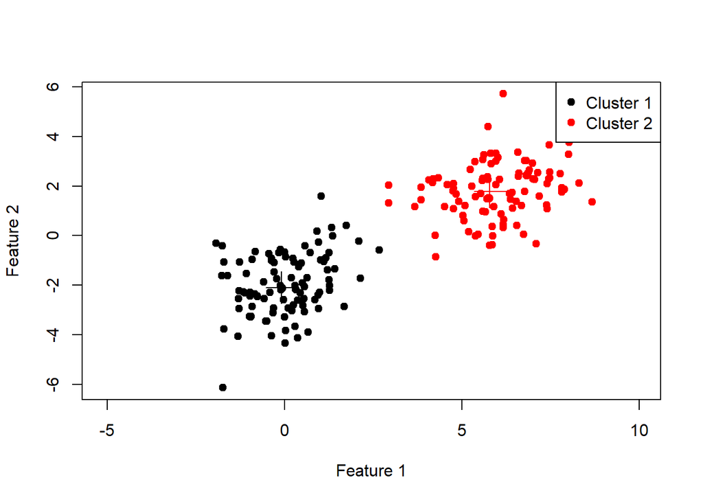

```r
# Update clusters
clusters_v3 <- cluster_assignment(x, centroids_v3)

plot(x, xlim = c(-5.1, 10), col = ifelse(clusters_v3 == 1, "black", "red"), pch = 19, xlab = "Feature 1", ylab = "Feature 2")
legend("topright", legend = c("Cluster 1", "Cluster 2"), col = c("black", "red"), pch = 19)
points(x = centroids_v3[1,1], y = centroids_v3[1,2], pch = 3, cex = 3, col = "black")
points(x = centroids_v3[2,1], y = centroids_v3[2,2], pch = 3, cex = 3, col = "red")
```

```r
# Update centroids
centroids_v4 <- update_centroids(x, clusters_v3, 2)
centroids_v4
```

```
##            [,1]      [,2]
## [1,] 0.02691074 -1.951524
## [2,] 6.03324639  1.869012
```

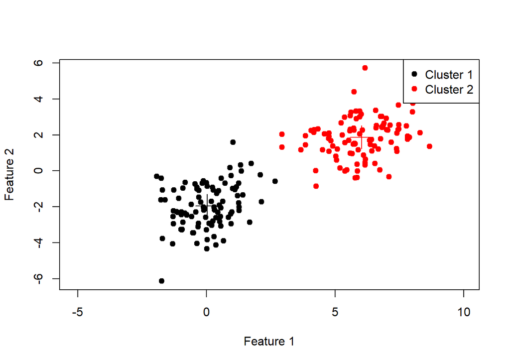

```r
# Plot with updated centroids
plot(x, xlim = c(-5.1, 10), col = ifelse(clusters_v3 == 1, "black", "red"), pch = 19, xlab = "Feature 1", ylab = "Feature 2")
legend("topright", legend = c("Cluster 1", "Cluster 2"), col = c("black", "red"), pch = 19)
points(x = centroids_v4[1,1], y = centroids_v4[1,2], pch = 3, cex = 3, col = "black")
points(x = centroids_v4[2,1], y = centroids_v4[2,2], pch = 3, cex = 3, col = "red")
```

```r
# Calculate objective function value
compute_distance(x, clusters_v3, centroids_v4)
```

```
## [1] 528.9369
```

The new objective value is 528.936906, which is a decrease of 71.7770285 compared to the objective value calculated using `centroids_v3`.

#### Iteration 4

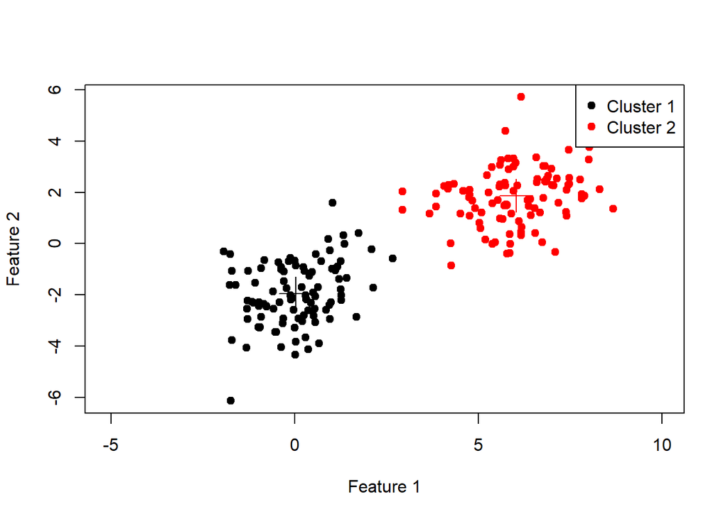

```r
# Update clusters
clusters_v4 <- cluster_assignment(x, centroids_v4)

plot(x, xlim = c(-5.1, 10), col = ifelse(clusters_v4 == 1, "black", "red"), pch = 19, xlab = "Feature 1", ylab = "Feature 2")
legend("topright", legend = c("Cluster 1", "Cluster 2"), col = c("black", "red"), pch = 19)
points(x = centroids_v4[1,1], y = centroids_v4[1,2], pch = 3, cex = 3, col = "black")
points(x = centroids_v4[2,1], y = centroids_v4[2,2], pch = 3, cex = 3, col = "red")
```

Notice that there seems no change to the plot compared to the most recent plot. We confirm that the k-means algo has indeed converged by checking element by element.

```r
clusters_v4 == clusters_v3
```

```
##   [1] TRUE TRUE TRUE TRUE TRUE TRUE TRUE TRUE TRUE TRUE TRUE TRUE TRUE TRUE TRUE
##  [16] TRUE TRUE TRUE TRUE TRUE TRUE TRUE TRUE TRUE TRUE TRUE TRUE TRUE TRUE TRUE
##  [31] TRUE TRUE TRUE TRUE TRUE TRUE TRUE TRUE TRUE TRUE TRUE TRUE TRUE TRUE TRUE
##  [46] TRUE TRUE TRUE TRUE TRUE TRUE TRUE TRUE TRUE TRUE TRUE TRUE TRUE TRUE TRUE
##  [61] TRUE TRUE TRUE TRUE TRUE TRUE TRUE TRUE TRUE TRUE TRUE TRUE TRUE TRUE TRUE
##  [76] TRUE TRUE TRUE TRUE TRUE TRUE TRUE TRUE TRUE TRUE TRUE TRUE TRUE TRUE TRUE
##  [91] TRUE TRUE TRUE TRUE TRUE TRUE TRUE TRUE TRUE TRUE TRUE TRUE TRUE TRUE TRUE
## [106] TRUE TRUE TRUE TRUE TRUE TRUE TRUE TRUE TRUE TRUE TRUE TRUE TRUE TRUE TRUE
## [121] TRUE TRUE TRUE TRUE TRUE TRUE TRUE TRUE TRUE TRUE TRUE TRUE TRUE TRUE TRUE
## [136] TRUE TRUE TRUE TRUE TRUE TRUE TRUE TRUE TRUE TRUE TRUE TRUE TRUE TRUE TRUE
## [151] TRUE TRUE TRUE TRUE TRUE TRUE TRUE TRUE TRUE TRUE TRUE TRUE TRUE TRUE TRUE
## [166] TRUE TRUE TRUE TRUE TRUE TRUE TRUE TRUE TRUE TRUE TRUE TRUE TRUE TRUE TRUE
## [181] TRUE TRUE TRUE TRUE TRUE TRUE TRUE TRUE TRUE TRUE TRUE TRUE TRUE TRUE TRUE
## [196] TRUE TRUE TRUE TRUE TRUE
```

Indeed, since there is no change to cluster assignment, there will be no change to the centroids, and the algorithm is terminated.